# Capstone Project

18 februari 2019

## Introduction

- Work made in the context of the Capstone project of the Data Science Specialization of Coursera
- Aim:
  - development of a next word prediction algorithm using Natural Language Processing
  - construction of a Shiny app

## Building the algorithm (1)

- Original corpus gathers sentences from Twitter (more than 2 000 000 sentences), News (77 000 sentences) and Blogs (900 000 sentences)
- Only the English texts were used
- Only 50% of the total corpus was used to build the algorithm
  - pre-treatment: remove profanity words, remove @, #, ponctuation,…
- Construction of N-grams
  - from 5 to 1-gram
  - words with a frequency lower than 4 were removed
  - saved as .txt files

## Building the algorithm (2)

- First corresponding 5-grams are looked for. If there are less than five 5-grams, then the search is also made in 4-grams. If there are still not five possibilities, then 3-grams are used and so on, until five possibilities are found.
- Scores are calculated following the Stupid Backoff method
- The most probable word is then determined
- The algorithm can be found in [Github](https://github.com/AmandineLigot/Capstone-Coursera)

## Shiny app

- The Shiny app can be found [here](https://amandineligot.shinyapps.io/Capstone/)

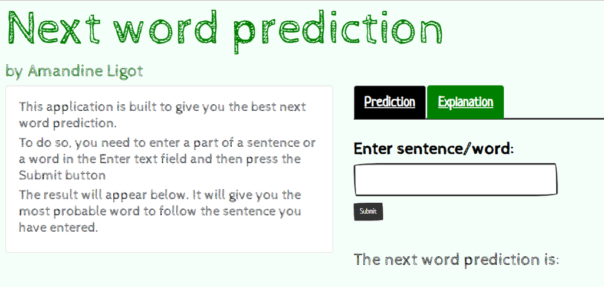

- A word or a sentence should be entered in the field
- Click on **Submit**
- The most probable word to follow the sentence is given